# Positioning of Panels

Richard Cotton

2024-04-09

When you add a plot or image to a multi-panel figure, you can specify which panels it should cover. The `fill_panel` function will automatically choose the next free location for you if you don’t specify it.

Here is a multi-panel figure with twelve panels.

```r
library(multipanelfigure)
library(grid)
cols <- 4
rows <- 3
figure <- multi_panel_figure(
  width = 135,
  columns = cols,
  height = 100,
  rows = rows)
```

We will fill the panels with colored rectangle. The next function is designed to change the color of the rectangle each time it is called. Don’t worry too much about its implementation.

```r
rect_grob <- function()
{
  this_env <- environment(rect_grob)
  assign("current", this_env$current + 1, this_env)
  rectGrob(gp = gpar(fill = rainbow(8)[this_env$current], alpha = 0.5))
}
assign("current", 0, environment(rect_grob))
```

If we don’t specify which panel to fill, `fill_panel` defaults to using the top-left panel.

```
## Setting row to 1
```

```
## Setting column to 1
```

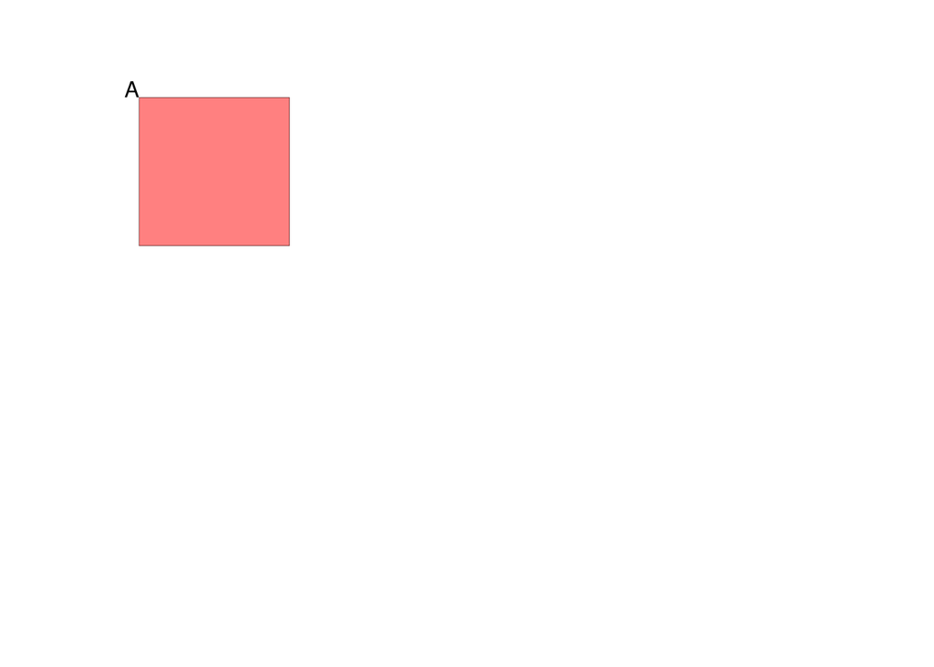

```r
(figure %<>% fill_panel(rect_grob()))
```

Next, the automatically chosen position is the second column on the top row. In general, the default position moves left to right, then top to bottom – just as you would read in most Roman, Greek, or Cyrillic scripts.

```
## Setting row to 1
```

```
## Setting column to 2
```

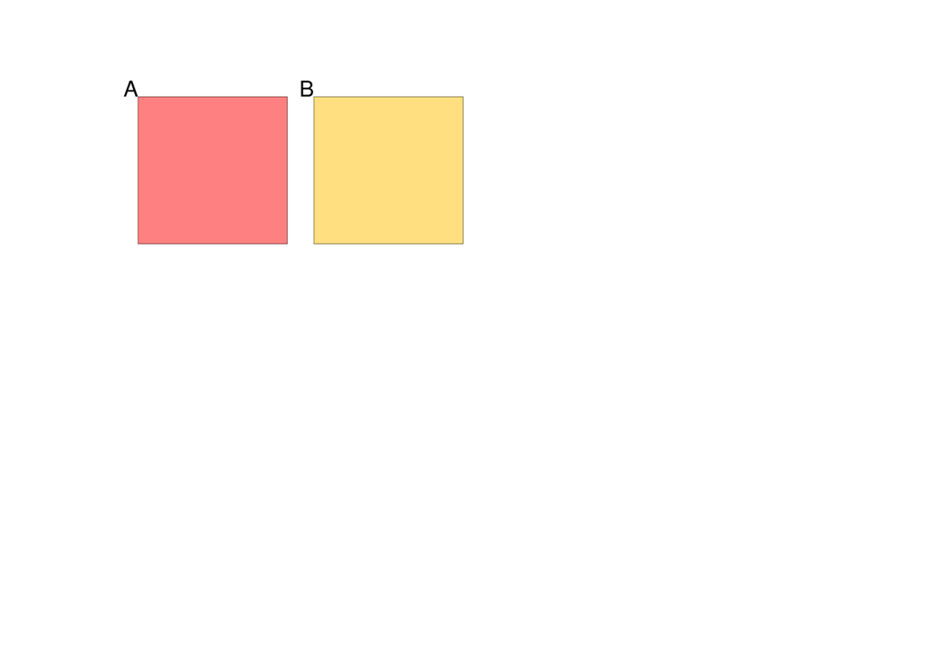

```r
(figure %<>% fill_panel(rect_grob()))
```

If you want to cover multiple panels, or specify a different position, you can manually set the `row` and `column` arguments. In the following example, `row` is set so that the rectangle covers rows one to three. The `column` argument specifies that the third column should be used; as it is of length one, the image only covers a single column.

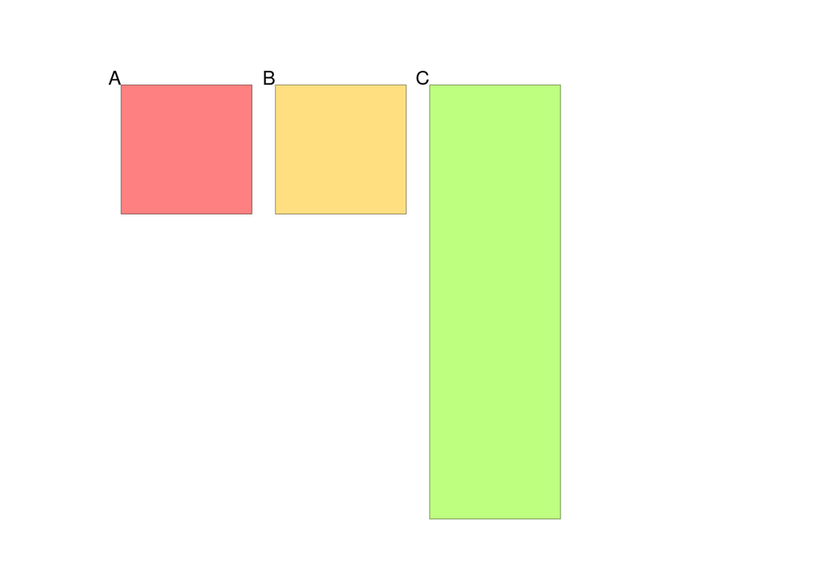

```r
(figure %<>% fill_panel(rect_grob(), row = 1:3, column = 3))
```

Now that the third column in the top row has been filled, the automatic positioning fills the fourth column in the top row.

```
## Setting row to 1
```

```
## Setting column to 4
```

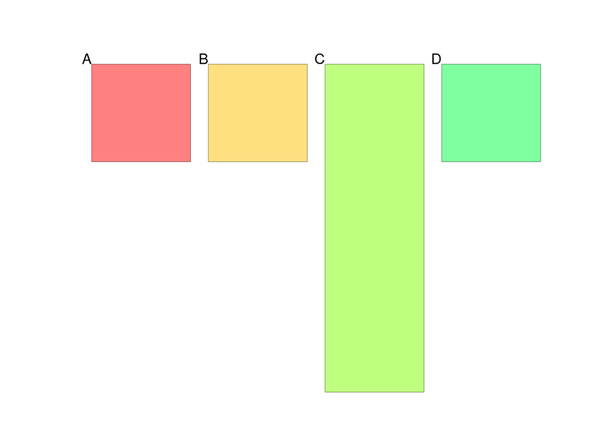

```r
(figure %<>% fill_panel(rect_grob()))
```

The top row is now completely full, so automatic positioning fills the first value in the second row.

```
## Setting row to 2
```

```
## Setting column to 1
```

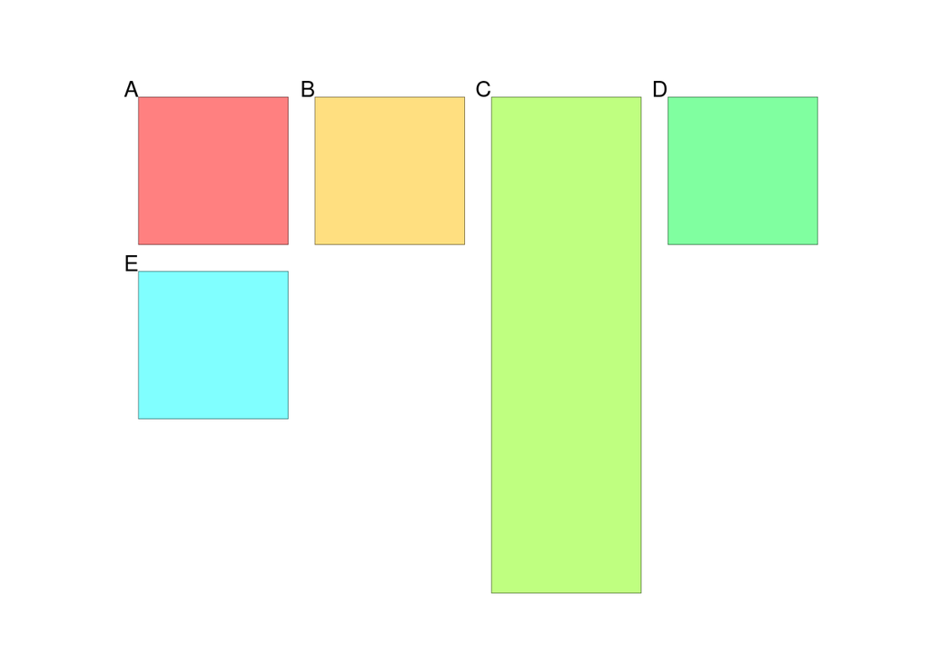

```r
(figure %<>% fill_panel(rect_grob()))
```

```
## Setting row to 2
```

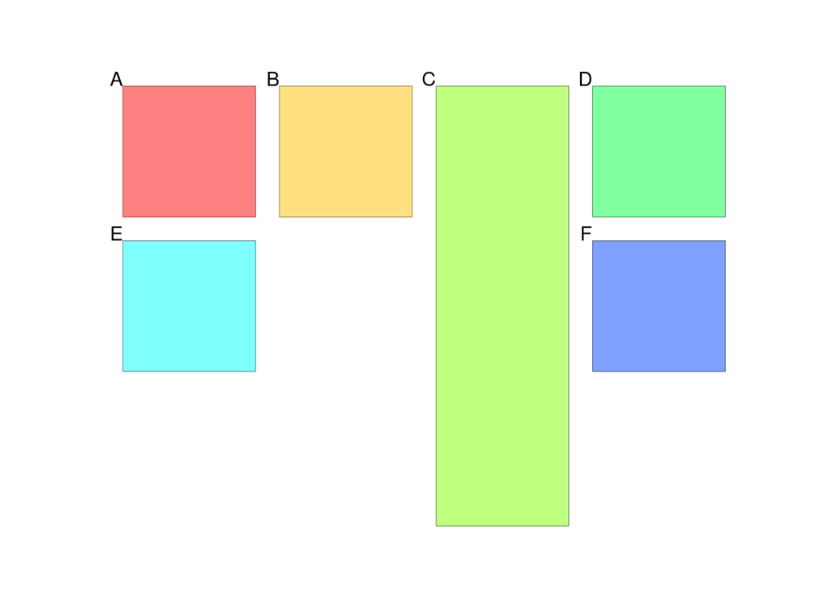

```r
(figure %<>% fill_panel(rect_grob(), column = 4))
```

Likewise, we can specify the third row, but use automatic positioning for the column.

```
## Setting column to 1
```

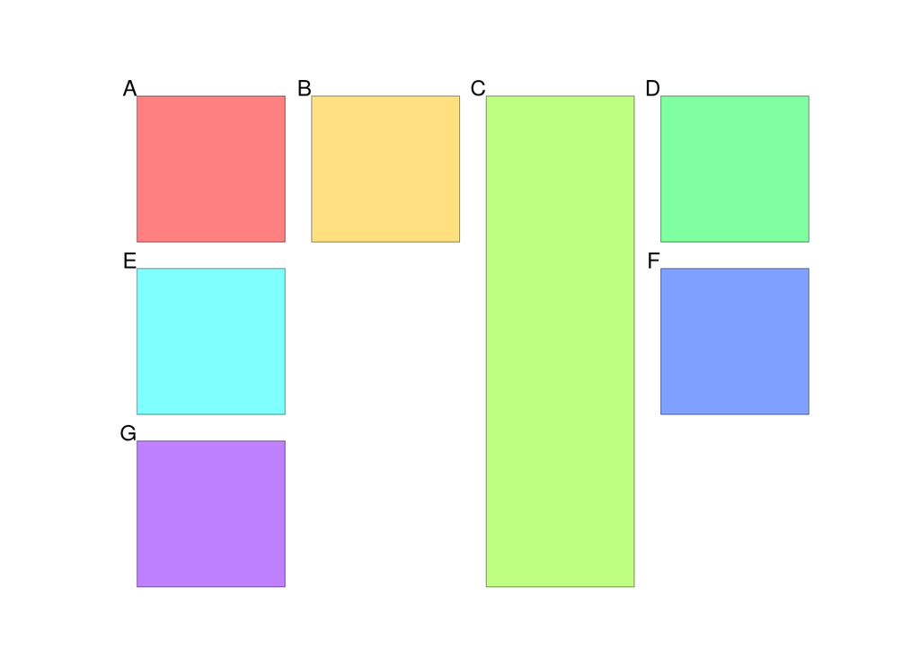

```r
(figure %<>% fill_panel(rect_grob(), row = 3))
```

```r
(figure %<>% fill_panel(rect_grob(), column = 2:3, row = 3))
```

```
## Error in fill_panel(., rect_grob(), column = 2:3, row = 3): Attempt to use these already filled panels.
##   row col
## 1   3   3
```

If we really want to overwrite the panel, we can set `allow_panel_overwriting = TRUE`. The overwritten panels will still be warned about.

```
## Warning in fill_panel(., rect_grob(), column = 2:3, row = 3, allow_panel_overwriting = TRUE): Attempt to use these already filled panels.
##   row col
## 1   3   3
```

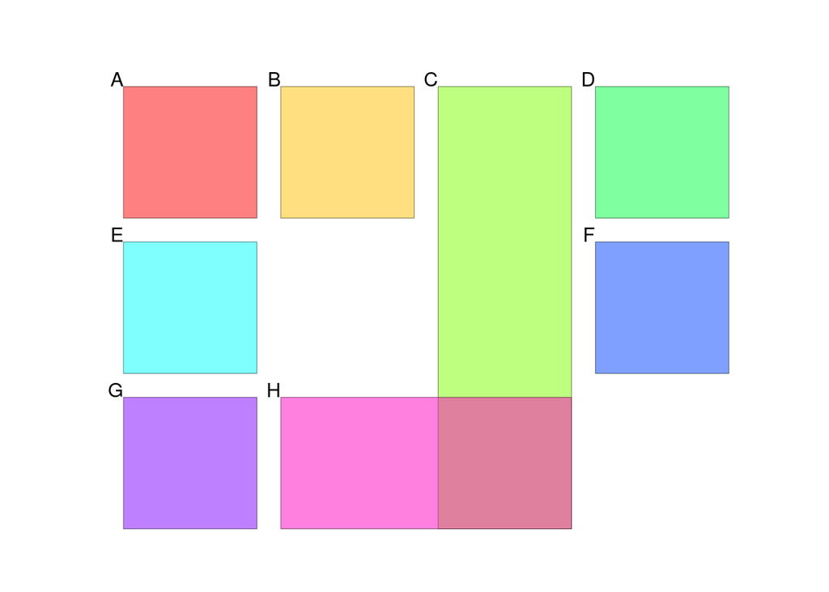

```r
(figure %<>% fill_panel(rect_grob(), column = 2:3, row = 3, allow_panel_overwriting = TRUE))
```